# **菊安酱与菜菜的Python机器学习可视化**

## 第五期 组成图 (1)

### 扫码回复K进群，获取本课课件~！

[figure not shown]

## 每周三晚上8点直播1小时，完整版2小时周日上线~

## 单数周菜菜直播，双数周菊安酱直播，哔哩哔哩与peixun.net同步开启

[figure not shown]

**注意：本篇中可能遇见无法在matpotlib和seaborn中显示中文或者负号的问题**  
如果你遇见了，请参考链接，可永久解决中文和负号问题：https://www.jianshu.com/p/914b5f4ce6bf  
或者你也可以在每次需要负号和中文的时候执行下面的代码来避免中文或负号显示不出来：

```python
import matplotlib.pyplot as plt
plt.rcParams['font.sans-serif']=['Simhei']
plt.rcParams['axes.unicode_minus']=False
```

[figure not shown]

## **第五章 组成图 Composition**

组成图是描述样本类别组成的图像，它能够直观表达一组数据集中有什么样的类别，并展现出不同类别所占的比例  
组成图往往有绚丽的色彩，在某一类别占比很大的时候能够让该类别非常显眼，所以是商业报告&PPT最佳伴侣！  
典型的组成图有：人民群众最熟悉的饼图，树形图和华夫饼图

[figure not shown]

### 31/50 华夫饼图

华夫饼图又叫做方形饼图(square chart)，是一种以方形饼图展示不同类别占比的组成图，通常为10x10网格，其中每个单元格代表1％的占比。

[figure not shown]

没有横坐标和纵坐标  
只有标题和图例，从图例中可以看出，一种颜色一种类别，每个格子表示了1%的占比  
三张图的类别分别是：Class(车辆类型)，Cyl(气缸数量)，Make(汽车制造商)

### 1. 导入需要的绘图库&基本设置

```python
import numpy as np
import pandas as pd
import matplotlib as mpl
import matplotlib.pyplot as plt
import seaborn as sns
import warnings; warnings.filterwarnings(action='once')

large = 22; med = 16; small = 12
params = {'axes.titlesize': large,
          'legend.fontsize': med,
          'figure.figsize': (16, 10),
          'axes.labelsize': med,
          'axes.titlesize': med,
          'xtick.labelsize': med,
          'ytick.labelsize': med,
          'figure.titlesize': large}
plt.rcParams.update(params)
plt.style.use('seaborn-whitegrid')
sns.set_style("white")
%matplotlib inline
```

[figure not shown]

### 2. 认识绘制华夫饼的库

#### **pywaffle.Waffle**

Python + 华夫饼的英文单词waffle形成的库pywaffle，是专门为matplotlib设计的，用来绘制一系列饼图的库  
其中的Waffle模块是专门绘制华夫饼图的，但神奇的是，我们不通过任何函数来实现这个功能  
这个库需要单独安装，大家可以运行以下代码进行安装：

```python
%%cmd
pip install pywaffle
```

```
Microsoft Windows [Version 10.0.17134.648]
(c) 2018 Microsoft Corporation. All rights reserved.

C:\Pythonwork\micro-class 2 - virtualization\week5>pip install pywaffle

C:\Pythonwork\micro-class 2 - virtualization\week5>
```

```python
#导入华夫饼库中的华夫饼模块
from pywaffle import Waffle
```

```python
Waffle #pywaffle库，waffle模块中的Waffle图像类型
```

```
pywaffle.waffle.Waffle
```

```python
type(Waffle) #本身就是一种类型
```

```
type
```

> **重要参数**

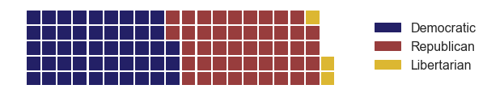

```python
#先画一块饼看看吧

data = {'Democratic': 48, 'Republican': 46, 'Libertarian': 3} #数据集以字典的形式表示，这里表示三种类别

fig = plt.figure(
    figsize=(8,3),
    FigureClass=Waffle,
    rows=5,
    values=data,
    colors=("#232066", "#983D3D", "#DCB732"), #颜色的数量必须要与数据中的类别数量一致，否则报错
    legend={'loc': 'upper right'
            , 'bbox_to_anchor': (1.5, 1)
           }
)

#loc与bbox_to_anchor用法梳理
#plt.scatter([0],[0]);
```

问题：华夫饼图一定得是100个格子吗？不输入类别的百分比，而是输入一个类别中的样本数量可以么？

[figure not shown]

### 3. 处理绘图用的数据

```python
#导入数据
df_raw = pd.read_csv("https://github.com/selva86/datasets/raw/master/mpg_ggplot2.csv")
```

```python
df_raw.head()
```

|  | manufacturer | model | displ | year | cyl | trans | drv | cty | hwy | fl | class |
| --- | --- | --- | --- | --- | --- | --- | --- | --- | --- | --- | --- |
| 0 | audi | a4 | 1.8 | 1999 | 4 | auto(l5) | f | 18 | 29 | p | compact |
| 1 | audi | a4 | 1.8 | 1999 | 4 | manual(m5) | f | 21 | 29 | p | compact |
| 2 | audi | a4 | 2.0 | 2008 | 4 | manual(m6) | f | 20 | 31 | p | compact |
| 3 | audi | a4 | 2.0 | 2008 | 4 | auto(av) | f | 21 | 30 | p | compact |
| 4 | audi | a4 | 2.8 | 1999 | 6 | auto(l5) | f | 16 | 26 | p | compact |

```python
name = ["汽车制造商","型号名称","发动机排量(L)","制造年份","气缸数量","手动/自动"
        ,"驱动类型","城市里程/加仑","公路里程/加仑","汽油种类","车辆种类"]

#驱动类型：四轮，前轮，后轮
#能源种类：汽油，柴油，用电等等
#车辆种类：皮卡，SUV，小型，中型等等
#城市里程/加仑，公路里程/加仑：表示使用每加仑汽油能够跑的英里数，所以这个数值越大代表汽车越节能
```

```python
#我们需要向华夫饼图输入类别和类别对应的数量
```

```python
df_raw.groupby("class").size() #提取出按照class来聚合之后每个类别下的样本数量
```

```
class
2seater        5
compact       47
midsize       41
minivan       11
pickup        33
subcompact    35
suv           62
dtype: int64
```

```python
df_raw.groupby("class").size().reset_index()
```

|  | class | 0 |
| --- | --- | --- |
| 0 | 2seater | 5 |
| 1 | compact | 47 |
| 2 | midsize | 41 |
| 3 | minivan | 11 |
| 4 | pickup | 33 |
| 5 | subcompact | 35 |
| 6 | suv | 62 |

```python
df_class = df_raw.groupby('class').size().reset_index(name='counts')
```

```python
n_categories = df_class.shape[0]
```

```python
#使用光谱和列表推倒式准备颜色
colors = [plt.cm.inferno_r(i/float(n_categories)) for i in range(n_categories)]
```

```python
plt.cm.inferno_r(0.5) #RGBA
```

```
(0.729909, 0.212759, 0.333861, 1.0)
```

```python
#依然列表推倒式，准备图例
```

```python
["{1}".format(n[0], n[1]) for n in df_class[['class', 'counts']].itertuples()]
```

```
['2seater', 'compact', 'midsize', 'minivan', 'pickup', 'subcompact', 'suv']
```

```python
df_class[['class', 'counts']]
```

|  | class | counts |
| --- | --- | --- |
| 0 | 2seater | 5 |
| 1 | compact | 47 |
| 2 | midsize | 41 |
| 3 | minivan | 11 |
| 4 | pickup | 33 |
| 5 | subcompact | 35 |
| 6 | suv | 62 |

```python
#intertuples：将一个dataframe的行当作元祖来进行循环的函数，有点类似与lambda，都是对DataFrame中的每行/每列中的对象进行操作
for n in df_class[['class', 'counts']].itertuples():
    print(n)
#元祖中有三个对象：索引，第一列“车辆类型”，第二列“计数”
```

```
Pandas(Index=0, _1='2seater', counts=5)
Pandas(Index=1, _1='compact', counts=47)
Pandas(Index=2, _1='midsize', counts=41)
Pandas(Index=3, _1='minivan', counts=11)
Pandas(Index=4, _1='pickup', counts=33)
Pandas(Index=5, _1='subcompact', counts=35)
Pandas(Index=6, _1='suv', counts=62)
```

```python
n[0]
```

```
6
```

```python
n[1]
```

```
'suv'
```

```python
#本质其实和这一段一样：
[n[1] for n in df_class[['class', 'counts']].itertuples()]
```

```
['2seater', 'compact', 'midsize', 'minivan', 'pickup', 'subcompact', 'suv']
```

```python
#数据准备（占比，颜色以及标签）

#按车辆类型
df_class = df_raw.groupby('class').size().reset_index(name='counts_class')
n_categories = df_class.shape[0]
colors_class = [plt.cm.Set3(i/float(n_categories)) for i in range(n_categories)]
#colors_class = [plt.cm.nipy_spectral(i/float(n_categories)) for i in range(n_categories)] #更换成了更容易查看的颜色
labels_class = [n[1] for n in df_class[['class', 'counts_class']].itertuples()] #更加简单的写法

#按气缸数量
df_cyl = df_raw.groupby('cyl').size().reset_index(name='counts_cyl')
n_categories = df_cyl.shape[0]
colors_cyl = [plt.cm.Spectral(i/float(n_categories)) for i in range(n_categories)]
#colors_cyl = [plt.cm.nipy_spectral(i/float(n_categories)) for i in range(n_categories)]
labels_cyl = ["{1}".format(n[0], n[1]) for n in df_cyl[['cyl', 'counts_cyl']].itertuples()]

#按制造商
df_make = df_raw.groupby('manufacturer').size().reset_index(name='counts_make')
n_categories = df_make.shape[0]
colors_make = [plt.cm.tab20b(i/float(n_categories)) for i in range(n_categories)]
#colors_make = [plt.cm.nipy_spectral(i/float(n_categories)) for i in range(n_categories)]
labels_make = ["{1}".format(n[0], n[1]) for n in df_make[['manufacturer', 'counts_make']].itertuples()]
```

[figure not shown]

### 4. 绘制华夫饼图

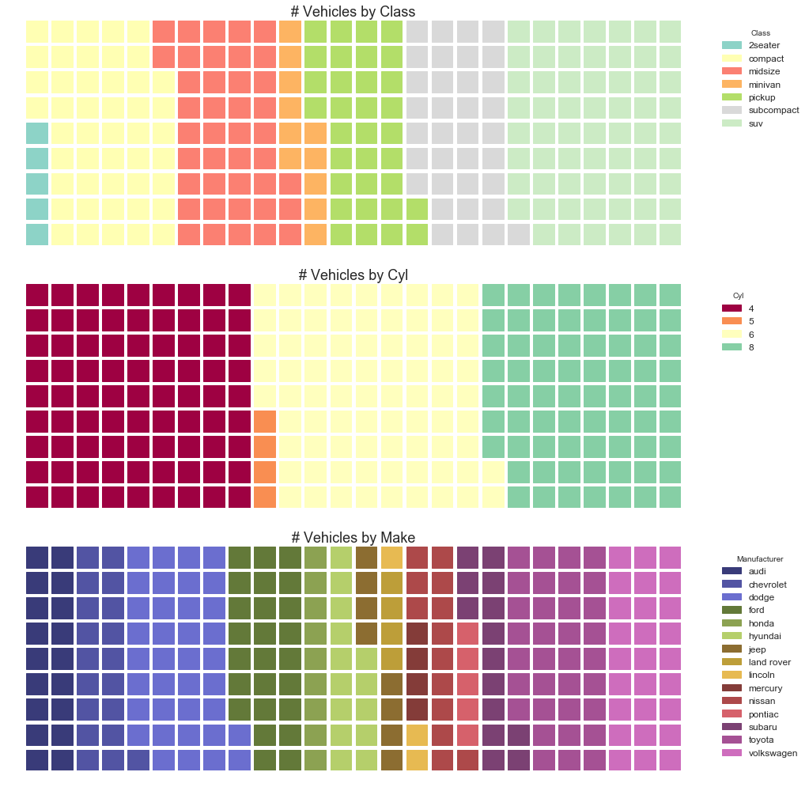

```python
#绘图
fig = plt.figure(
    FigureClass=Waffle,
    plots={
        '311': #这里的数字表示，3行，1列，索引为1的图
        {'values': df_class['counts_class'],
         'labels': labels_class,
         'legend': {'loc': 'upper left', 'bbox_to_anchor': (1.05, 1), 'fontsize': 12, 'title':'Class'},
         'title': {'label': '# Vehicles by Class', 'loc': 'center', 'fontsize':18},
         'colors': colors_class
        },
        '312': {
            'values': df_cyl['counts_cyl'],
            'labels': labels_cyl,
            'legend': {'loc': 'upper left', 'bbox_to_anchor': (1.05, 1), 'fontsize': 12, 'title':'Cyl'},
            'title': {'label': '# Vehicles by Cyl', 'loc': 'center', 'fontsize':18},
            'colors': colors_cyl
        },
        '313': {
            'values': df_make['counts_make'],
            'labels': labels_make,
            'legend': {'loc': 'upper left', 'bbox_to_anchor': (1.05, 1), 'fontsize': 12, 'title':'Manufacturer'},
            'title': {'label': '# Vehicles by Make', 'loc': 'center', 'fontsize':18},
            'colors': colors_make
        }
    },
    rows=9,
    figsize=(16, 14),
   # icons='car', icon_size=25,
   # icon_legend=True
)
```

[figure not shown]

在使用icon时，你可能会遇见报错的情况：

[figure not shown]

**如果你出现类似的报错，请参考下面的步骤解决问题：**

**1. 进入网址：https://fontawesome.com/download**  
**2. 点击Free for Desktop进行下载**

[figure not shown]

**3. 找到fontawesome-free-5.8.1-desktop文件夹，点击进入，找到文件夹otfs中的文件：**

[figure not shown]

**4. 把三个otf文件复制到你的Python安装目录的字体文件夹下：C:\Python\Lib\site-packages\font**

[figure not shown]

### 5. 解读图像 & 华夫饼图展开

二分类的华夫饼：常用于企业KPI数据，完成任务了么？完成了多少？

[figure not shown]

> 华夫饼适合什么时候用呢？

> > 比较许多同一层级的不同类型，并探索这些类型如何对整体做出贡献  
> > 整体中的某一部分占比巨大  
> > 使用KPI图表作为总数的百分比

> 什么时候不应该用华夫饼？

> > 当对整体有贡献的类别太多的时候，华夫饼图能够展现的组成情况有限  
> > 测量的KPI或者总贡献可以超过100%时  
> > 华夫饼展现出“大概的比例”，当精确的占比（比如百分比数量）非常重要的时候，必须借助文字帮助

[figure not shown]

### 32/50 饼图，33/50 树型图，34/50 条形图

[figure not shown]